# **CS 598 PSL - Coding Assignment 1**

Fall 2020, **Sezgin Kucukcoban

09/14/2020

[Instructor] Here we hide the author’s code for setting seed so that we don’t give away information about author’s UIN. The title and file name has also been modified to not give away author’s netID

First let’s load required `R` packages and set the seed.

```r
library(class)
library(ggplot2)
```

## 1) Data Generation

We need to sample two-dimensional data $X \in \mathbf{R}^2$ in each class from a mixture of 10 different bivariate Gaussian distributions with uncorrelated components and different means, i.e.,

$$X \ |\ Y=k, \ Z=l \ \sim \ \mathcal{N}(\mathbf{m}_{kl}, s^2 \mathbf{I}_2),$$

where

- $k = 0, 1$
- $l = 1:10$
- $P(Y=k) = 1/2$
- $P(Z=l) = 1/10$.

In other words, given $Y = k$, $X$ follows a mixture distribution with density function

$$\frac{1}{10}\sum_{l=1}^{10} \left( \frac{1}{\sqrt{2\pi s^2}} \right)^2 e^{-\| \mathbf{x}- \mathbf{m}_{kl}\|^2 / (2s^2)}.$$

Let’s define two functions. `generateCenters` produces center points to be used with `generateData` that takes inputs from user and returns simulated data sets (*train* and *test*).

```r
# nc  : number of cluster centers
# sdc : standard deviation for generating the cluster centers
#
generateCenters = function(nc, sdc) {
  # generate cluster center points
  m1 = matrix(rnorm(nc * 2), nc, 2) * sdc + cbind(rep(1, nc), rep(0, nc))
  m0 = matrix(rnorm(nc * 2), nc, 2) * sdc + cbind(rep(0, nc), rep(1, nc))

  return(list("center0" = m0,
              "center1" = m1))
}
```

```r
# centers : cluster center points
# ntr     : number of training samples
# nte     : number of test samples
# sdd     : standard deviation for generating the data
#
generateData = function(centers, ntr, nte, sdd) {
  # training data
  y = rep(0, ntr)
  x1 = rep(0, ntr)
  x2 = rep(0, ntr)
  for (i in 1:ntr) {
    y[i] = sample(0:1, 1)
    z = sample(1:10, 1)
    x1[i] = rnorm(1, mean = centers[[y[i] + 1]][z, 1], sd = sdd)
    x2[i] = rnorm(1, mean = centers[[y[i] + 1]][z, 2], sd = sdd)
  }
  train_set = data.frame("X1" = x1, "X2" = x2, "Y" = y)

  # test data
  y = rep(0, nte)
  x1 = rep(0, nte)
  x2 = rep(0, nte)
  for (i in 1:nte) {
    y[i] = sample(0:1, 1)
    z = sample(1:10, 1)
    x1[i] = rnorm(1, mean = centers[[y[i] + 1]][z, 1], sd = sdd)
    x2[i] = rnorm(1, mean = centers[[y[i] + 1]][z, 2], sd = sdd)
  }
  test_set = data.frame("X1" = x1, "X2" = x2, "Y" = y)

  return(list("train" = train_set,
              "test" = test_set))
}
```

## 2) Classification Procedures

### 2.a) Linear regression

Let’s define a function `linearPerf` to fit a linear regression model on the training data and use cut-off value $0.5$ to transform numerical outcomes to binary outcomes.

```r
linearPerf = function(train, test) {
  # fit linear regression
  reg = lm(Y ~ X1 + X2, data = train)

  # predict train and test Y
  Ytrain_pred = as.numeric(reg$fitted > 0.5)
  Ytest_pred = predict(reg, newdata = test)
  Ytest_pred = as.numeric(Ytest_pred > 0.5)

  # calculate errors
  train_err = sum(train[, "Y"] != Ytrain_pred) / length(Ytrain_pred)
  test_err = sum(test[, "Y"] !=  Ytest_pred) / length(Ytest_pred)

  return(list("method" = "Linear",
              "model" = reg,
              "trainError" = train_err,
              "testError" = test_err,
              "info1" = NA,
              "info2" = NA))
}
```

### 2.b) Quadratic regression

Let’s define a function `quadraticPerf` to fit a quadratic regression model on the training data and use cut-off value $0.5$ to transform numerical outcomes to binary outcomes.

```r
quadraticPerf = function(train, test) {
  # fit linear regression
  reg = lm(Y ~ X1 + X2 + I(X1 * X2) + I(X1 ^ 2) + I(X2 ^ 2), data = train)

  # predict train and test Y
  Ytrain_pred = as.numeric(reg$fitted > 0.5)
  Ytest_pred = predict(reg, newdata = test)
  Ytest_pred = as.numeric(Ytest_pred > 0.5)

  # calculate errors
  train_err = sum(train[, "Y"] != Ytrain_pred) / length(Ytrain_pred)
  test_err = sum(test[, "Y"] !=  Ytest_pred) / length(Ytest_pred)

  return(list("method" = "Quadratic",
              "model" = reg,
              "trainError" = train_err,
              "testError" = test_err,
              "info1" = NA,
              "info2" = NA))
}
```

### 2.c) *k*NN with *k* chosen by CV

Let’s define a function `knnPerf` to calculate the misclassification rates using the *k*NN classifier (with cross-validation) on training and test datasets. Since we need to repeatedly perform classification to find optimal *k*, let’s define `AveErrRate_knnCV` function to compute the *n*-fold CV with a particular *k* value. Then, we can use the command `sapply` to apply the same function for various *k* values to find the best *k* for the classifier.

```r
# n_fold    : number of cross-validation folds
# fold_size : size of each cross-validation fold
# k         : number of nearest neighbors to consider
#
AveErrRate_knnCV = function(k, dataset, n_fold, fold_size) {
  error = 0
  myIndex = sample(1:nrow(dataset))

  for (runId in 1:n_fold) {
    testSetIndex = ((runId - 1) * fold_size + 1):
                    (ifelse(runId == n_fold, nrow(dataset), runId * fold_size))
    testSetIndex = myIndex[testSetIndex]

    trainX = dataset[-testSetIndex, c("X1", "X2")]
    trainY = as.factor(dataset[-testSetIndex,]$Y)
    testX = dataset[testSetIndex, c("X1", "X2")]
    testY = as.factor(dataset[testSetIndex,]$Y)

    predictY = knn(trainX, testX, trainY, k)
    error = error + sum(predictY != testY)
  }
  error = error / nrow(dataset)
  return(error)
}
```

```r
knnPerf = function(train, test, n_fold) {
  fold_size = floor(nrow(train)/n_fold)

  # k values to try
  k_vector = seq(1, (nrow(train) - fold_size), 2)

  # average error rates for various k values
  AveErrRates = sapply(k_vector, AveErrRate_knnCV, train, n_fold, fold_size)

  # find best k and associated cv error
  bestK = max(k_vector[AveErrRates == min(AveErrRates)])
  cvError = AveErrRates[bestK]

  # make predictions using best K
  Ytrain = as.factor(train$Y)
  Ytrain_pred = knn(train[,c("X1", "X2")], train[,c("X1", "X2")], Ytrain, bestK)
  Ytest_pred = knn(train[,c("X1", "X2")], test[,c("X1", "X2")], Ytrain, bestK)
  Ytest = as.factor(test$Y)

  # calculate errors
  train_err = sum(Ytrain != Ytrain_pred) / length(Ytrain_pred)
  test_err = sum(Ytest !=  Ytest_pred) / length(Ytest_pred)

  return(list("method" = "kNN",
              "model" = NA,
              "trainError" = train_err,
              "testError" = test_err,
              "info1" = bestK,
              "info2" = cvError))
}
```

### 2.d) Bayes Rule

Let’s define a function `BayesRulePerf` to calculate the misclassification rates using the Bayes Rule on training and test datasets. Since we need to repeatedly evaluate a mixture of normal distributions with 10 components on each point, let’s define `mixnorm` function first to perform the following calculation. Then, we can use the command `apply` to apply the same function on each row of the data.

$$\text{mixnorm_ratio} = \frac{\sum_{l=1}^{10} \exp{\{-\frac{1}{2s^2}\|m_{1l}-x\|^2}\} }{\sum_{l=1}^{10} \exp{\{-\frac{1}{2s^2}\|m_{0l}-x\|^2}\}}$$

```r
mixnorm = function(x, centers0, centers1, s){
  ## return the density ratio for a point x, where each
  ## density is a mixture of normal with multiple components
  d1 = sum(exp(-apply((t(centers1) - x)^2, 2, sum) / (2 * s^2)))
  d0 = sum(exp(-apply((t(centers0) - x)^2, 2, sum) / (2 * s^2)))

  return (d1 / d0)
}
```

```r
BayesRulePerf = function(train, test, centers0, centers1, s) {
  # predict train and test Y
  Ytrain_pred = apply(train[c("X1", "X2")], 1, FUN=function(x) mixnorm(x, centers0, centers1, s))
  Ytrain_pred = as.numeric(Ytrain_pred > 1)
  Ytest_pred = apply(test[c("X1", "X2")], 1, FUN=function(x) mixnorm(x, centers0, centers1, s))
  Ytest_pred = as.numeric(Ytest_pred > 1)

  # calculate errors
  train_err = sum(train[, "Y"] != Ytrain_pred) / length(Ytrain_pred)
  test_err = sum(test[, "Y"] !=  Ytest_pred) / length(Ytest_pred)

  return(list("method" = "Bayes Rule",
              "model" = NA,
              "trainError" = train_err,
              "testError" = test_err,
              "info1" = NA,
              "info2" = NA))
}
```

## 3) Simulations

We are ready to perform our simulations. Let’s simulate 20 different data sets.

```r
#parameters
n_center = 10          # number of cluster centers
n_train = 200          # number of training samples
n_test = 10000         # number of test samples
n_fold = 10            # number of cross-validation folds for kNN classifier
sd_center = 3          # standard deviation for generating the cluster centers
sd_data = sqrt(3 / 5)  # standard deviation for generating the data
n_sim = 20             # number of simulations

# generate random centers
centers = generateCenters(n_center, sd_center)

# simulate training and test data
sim_data = list()
for (i in 1:n_sim) {
  sim_data[[i]] = generateData(centers, n_train, n_test, sd_data)
}
```

Now let’s calculate train and test errors for each procedure using functions defined earlier.

```r
# reserve space
sim_lin = vector("list", length = n_sim)
sim_qua = vector("list", length = n_sim)
sim_knn = vector("list", length = n_sim)
sim_bys = vector("list", length = n_sim)

# perform simulations
for (i in 1:n_sim) {
  data = sim_data[[i]]
  sim_lin[[i]] = linearPerf(data$train, data$test)
  sim_qua[[i]] = quadraticPerf(data$train, data$test)
  sim_knn[[i]] = knnPerf(data$train, data$test, n_fold)
  sim_bys[[i]] = BayesRulePerf(data$train, data$test, centers[[1]], centers[[2]], sd_data)
}

# store results
sim_results = data.frame(rbind(do.call(rbind, sim_lin),
                               do.call(rbind, sim_qua),
                               do.call(rbind, sim_knn),
                               do.call(rbind, sim_bys)))
```

Let’s reshape the `sim_results` and create two new `data.frame`s that summarize error rate and best *k* related data. We will use these while generating the plots.

```r
# reshape results
sim_results$method = as.character(sim_results$method)
sim_results$trainError = as.numeric(sim_results$trainError)
sim_results$testError = as.numeric(sim_results$testError)
sim_results$info1 = as.numeric(sim_results$info1)
sim_results$info2 = as.numeric(sim_results$info2)

sim_perf = data.frame(
  "method" = rep(sim_results$method, 2),
  "error" = c(sim_results$trainError, sim_results$testError),
  "set" = c(rep("train", n_sim * 4), rep("test", n_sim * 4))
)
kNN_info = data.frame(
  "id" = seq(1, n_sim),
  "bestK" = sim_results$info1[(2 * n_sim + 1):(3 * n_sim)],
  "cvError" = sim_results$info2[(2 * n_sim + 1):(3 * n_sim)]
)
```

Finally, let’s compare performances of all methods graphically.

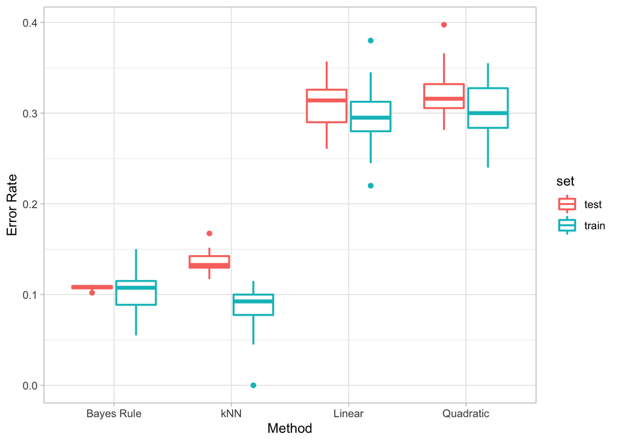

```r
ggplot(sim_perf, aes(x=as.factor(method), y=error, color=set)) +
    geom_boxplot("size"=0.75) + theme_light() +
    xlab("Method") + ylab("Error Rate")
```

The following bar chart displays best *k* selected by 10-fold cross-validation *k*NN classifier.

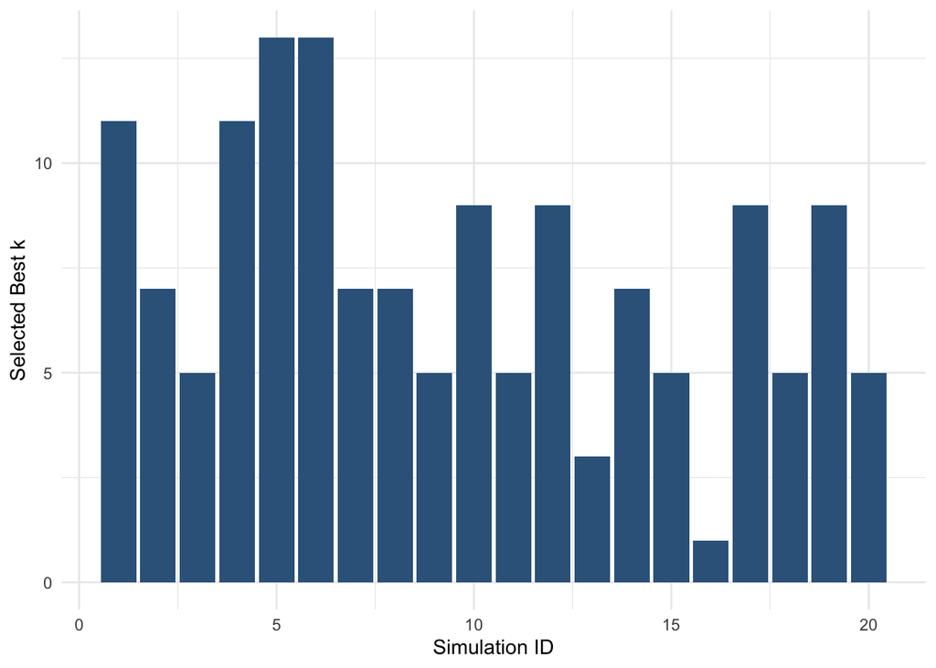

```r
ggplot(kNN_info, aes(x=id, y=bestK)) +
    geom_bar(stat="identity",fill="steelblue4") + theme_minimal() +
    xlab("Simulation ID") + ylab("Selected Best k")
```

The mean of the selected *k* values:

```r
mean(kNN_info$bestK)
```

```
## [1] 7.3
```

The standard deviation of the selected *k* values:

```r
sd(kNN_info$bestK)
```

```
## [1] 3.197038
```